# Спектральный анализ.Кепстр

© Alexander Doynikov,dep.Statisical Analysis, CS, MSU

30 октября 2017 г

# Спектральный анализ

## Периодограмма

Будем искать представление случайнного процесса в виде

$x_{t}=\alpha_0+\sum_{i=1}^{q}(\alpha_{i}c_{it}+\beta_{i}s_{it})+\epsilon_{t}$

Где

$c_{it}=cos2π\lambda_{i}t , s_{it}=sin2π\lambda_{i}t, \lambda_{i}=(i/N),i=1,...,q,N=2q+1$

Оценка наименьших квадратов параметров $\alpha_i,\beta_i$
$$\alpha_0=\sum_{t=1}^{N}x_{i}=x$$

$$\alpha_{i}=(2/N)\sum_{t=1}^{N}x_{t}c_{it}, i=1,...,q$$

$$\beta_{i}=(2/N)\sum_{t=1}^{N}x_{t}s_{it}, i=1,...,q$$

Рассмотрим функцию вида

$$I(\lambda_{i})=(N/2)(a_{i}^2+b_{i}^2), i=1,...,q$$

Эта функция получила название периодограммы. Для примера рассмотрим детерминированный ряд

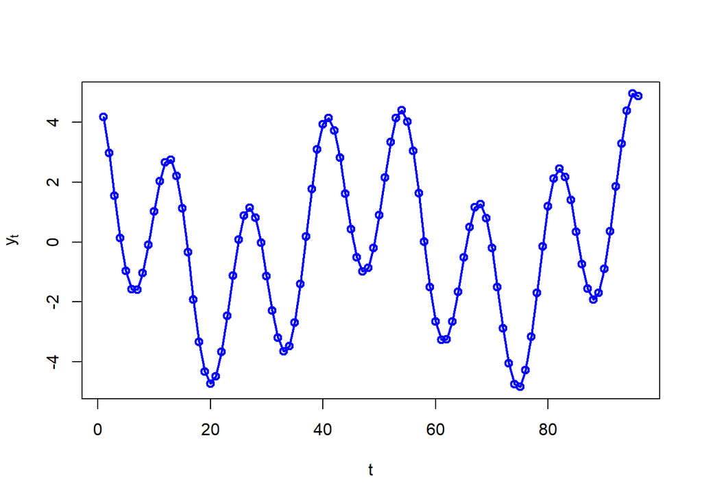

```r
t<- 1:96
cos1<- cos(1*pi*t*4/96)
cos2<- cos(1*pi*t*14/96+0.3)
y <-2*cos1+3*cos2
plot(t,y, type = "o",ylab= expression(y[t]),col = "blue",lwd = 2)
```

Периодограмма для ряда $y_t$

```r
library(TSA)
```

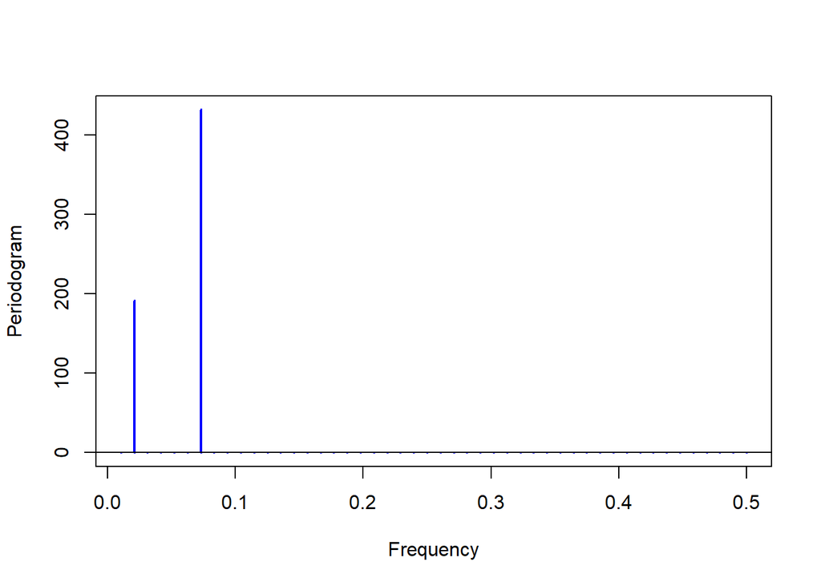

```r
periodogram(y,col = "blue",lwd = 2)
abline(h=0)
```

Теперь добавим шум. Для двух случайно выбранных частот из набора частот $[1/96,2/96,...,47/96$], амплитуды $a,b$ также выберем случайно и добавим белый шум Итак модель будет

$$y_t= A_1cos(2\pi f_1 t)+B_1sin(2\pi f_1t )+A_2cos(2\pi f_2 t)+B_2sin(2\pi f_2t )+\epsilon_t$$

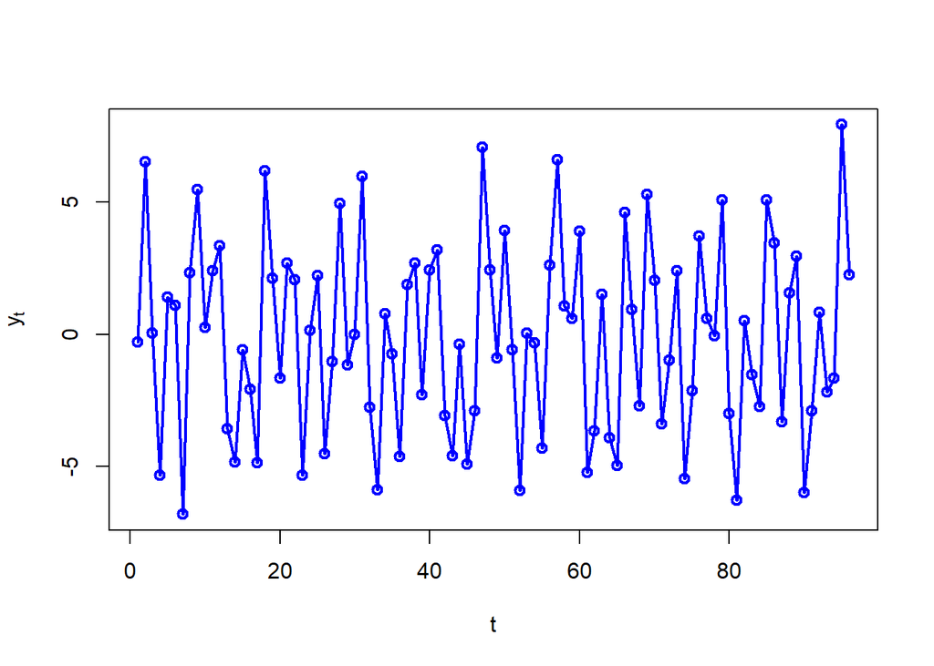

```r
set.seed(134); t=1:96; integer=sample(48,2)
freq1=integer[1]/96; freq2=integer[2]/96
A1=rnorm(1,0,2); B1=rnorm(1,0,2)
A2=rnorm(1,0,3); B2=rnorm(1,0,3); w=2*pi*t
y=A1*cos(w*freq1)+B1*sin(w*freq1)+A2*cos(w*freq2)+
B2*sin(w*freq2)+rnorm(96,0,1)
plot(t,y,type='o',ylab=expression(y[t]),col="blue",lwd=2)
```

Периодичность и частоты этих периодичностей весьма не очевидны. Построим периодограмму

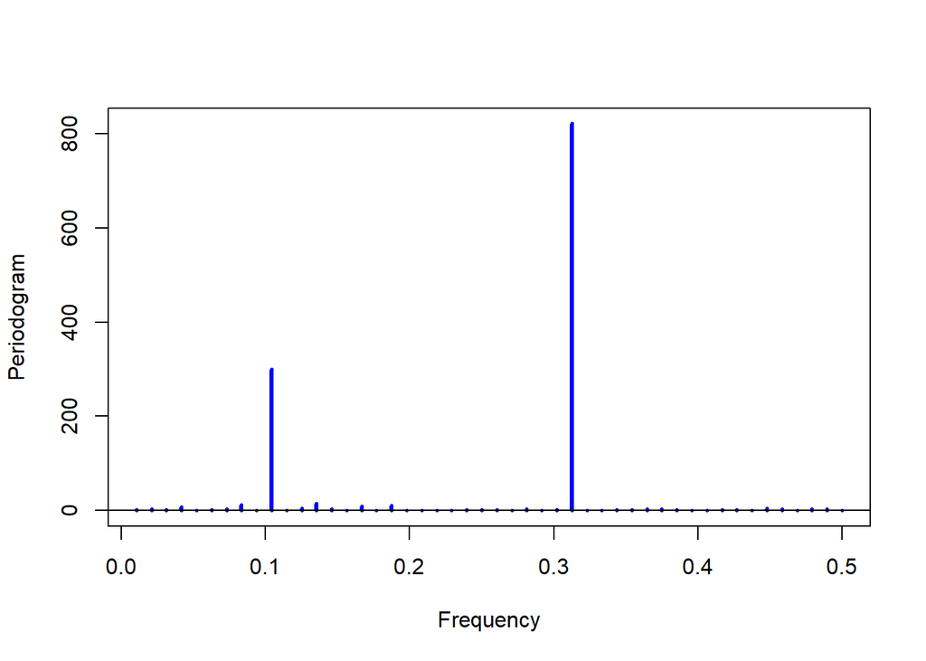

```r
periodogram(y, col = "blue",lwd = 3)
abline(h=0)
```

Где выбранные частоты становится очевидно.

## Cпектральная плотность

При определении периодограммы мы предполагали, что частоты $\lambda_{i}=(i/N)$. При переходе к спектру мы ослабим это предположение, считая, что частота $\lambda$ непрерывно в диапазоне от 0 до 0.5. При этом определение периодограммы примет вид

$I(λ)=(N/2)(a_{\lambda}^2+b_{\lambda}^2), \lambda∈[0,0.5]$

Эту функцию будем называть выборочным спектром. Справедливо следующее важное утверждение.

Теорема 1. *Выборочный спектр - косинус-преобразование Фурье автоковариационной функции.*

Доказательство

Обозначим через $d _{ \lambda}$ - комплексное число равное разности оценки амплитуды косинусоидальной и синуcоидальной составляющей умноженной на $i=\sqrt{-1}$

$d _{ \lambda}=a_{ \lambda}-ib_{ \lambda}$

Тогда выражение для выборочного спектра можно переписать следующим образом.

$I(\lambda)=(N/2)(a_{\lambda}^2+b_{\lambda}^2)=(N/2)(a_{\lambda}-ib_{\lambda})(a_{\lambda}+ib_{\lambda})=(N/2)d_{\lambda}d_{\lambda}'$

Из формул для оценок наименьших квадратов имеем

$d_{\lambda}=(2/N)[\sum_{t=1}^{N} x_{t}c_{\lambda}t -i\sum_{t=1}^{N}x_{t} s_{\lambda}t]=(2/N)[\sum_{t=1}^{N} x_{t}cos(2\pi\lambda t) -i\sum_{t=1}^{N}x_{t} sin(2\pi\lambda t]= (2/N)\sum_{t=1}^{N} x_{t}e^{-2\pi\ i\lambda t}=$

$(2/N)\sum_{t=1}^{N} (x_{t}-\overline x)e^{-2\pi\ i\lambda t}$

Подставляя полученное выражение в формулу для спектра, получим

$I(\lambda)=(N/2)d _{\lambda}d _{\lambda}'= (N/2)( (2/N) \sum_{t=1}^{N} (x_{t}-\overline x)e^{-2\pi i \lambda t}) ((2/N)\sum_{t'=1}^{N}(x_{t}-\overline x)e^{-2\pi i \lambda t′})=$

$(2/N)\sum_{t=1}^{N}\sum_{t′=1}^{N}(x_{t}-x)(x_{t′}-x)e^{-2\pi i\lambda (t-t′)}$=

Меняя порядок суммирования, и ,обозначив $k=t-t′$, последнее выражение можно переписать

$2/N\sum_{k=-N+1}^{N+1}e^{-2\pi i\lambda k} \sum_{t=1}^{N-k}(x_t-\overline x)(x_{t+k}-\overline x)$

Так как

$c_k =\frac{\sum_{t=1}^{N-k}(x_t-\overline x)(x_{t+k}-\overline x)}{N}$

Получим

$I_{N}(\lambda)=2\sum_{k=-N+1}^{N-1}с_{k}e^{-2\pi i\lambda k}$ $=2[c_0+2\sum_{k=1}^{N-1}c_{k}cos(2\pi\lambda k)]$

## Спектральное представление автоковариационной функции случайного процесса

Пусть $x_t$ стационарный случайный процесс, $c_k, k = 0,\pm 1,\pm 2,...,\pm \infty$ его автоковариационная функция. Справедливо следующее представление для АКФ стационарного случайного процесса

$с_k=\int_{-0.5}^{0.5}e^{2\pi\lambda k}dF(\lambda)$

Это выражение называется спектральным представлением АКФ. Функция $F(\lambda)$ называется спектральной функцией случайного процесса. В случае абсолютной непрерывности $F(\lambda)$ последнее выражение записывают как

$с_k=\int_{-0.5}^{0.5}e^{2\pi i\lambda k}f(\lambda)d\lambda$

где $f(\lambda)$- называют спектральной плотностью.

И наоборот

$f\lambda) = \sum_{k=-\infty}^{\infty}c_k e^{-2\pi i\lambda k}= c_0+2\sum_{k=1}^{\infty}c_kcos(2\pi\lambda k)$

## Свойства спектра

1. $F(\lambda)$ не убывает
2. непрервывна справа

3.$F(\lambda)$ >0

4. $\lim_{\lambda -> 1/2} F(\lambda)= D[(x_t)] = c_0$

## Спектральная плотность белого шума

Непосредственно из выражения

$f\lambda) = c_0+2\sum_{k=1}^{\infty}c_kcos(2\pi\lambda k)$

следует, что для белого шума $f(\lambda)= c_0=\sigma_{\epsilon}^2$ это объясняет слово “белый” в названии шума.

Cмоделируем белый шум и посмотрим его периодограмму

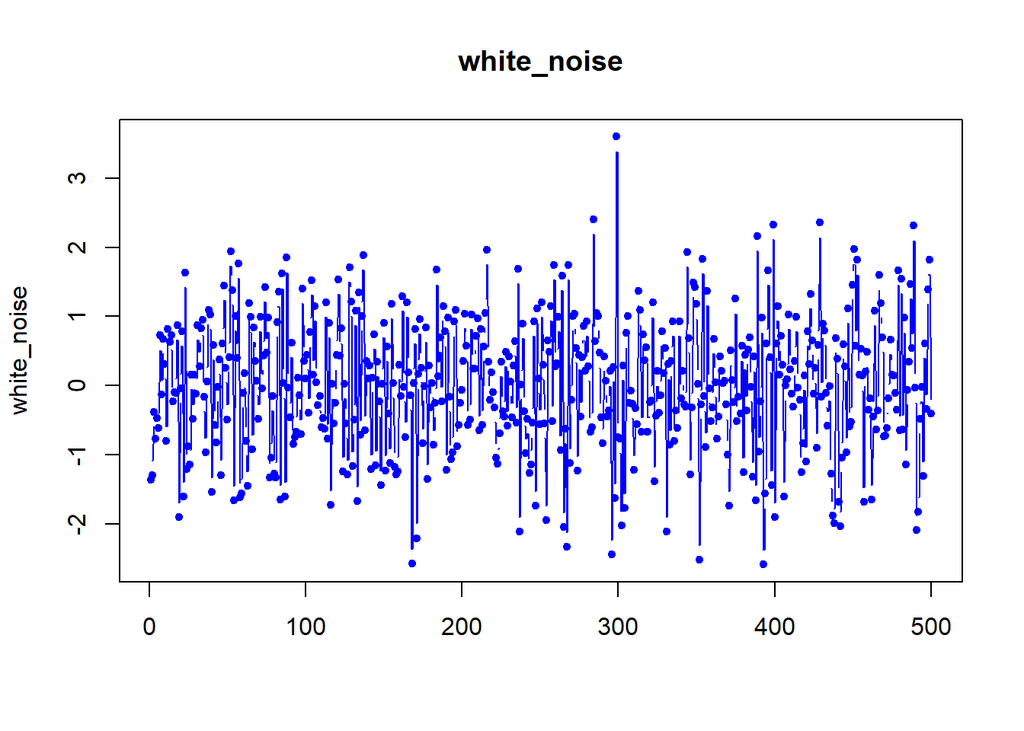

```r
white_noise <- rnorm(500)
matplot(white_noise,type ="b",lty = 1,pch = 20,main = 'white_noise',col = 'blue')
```

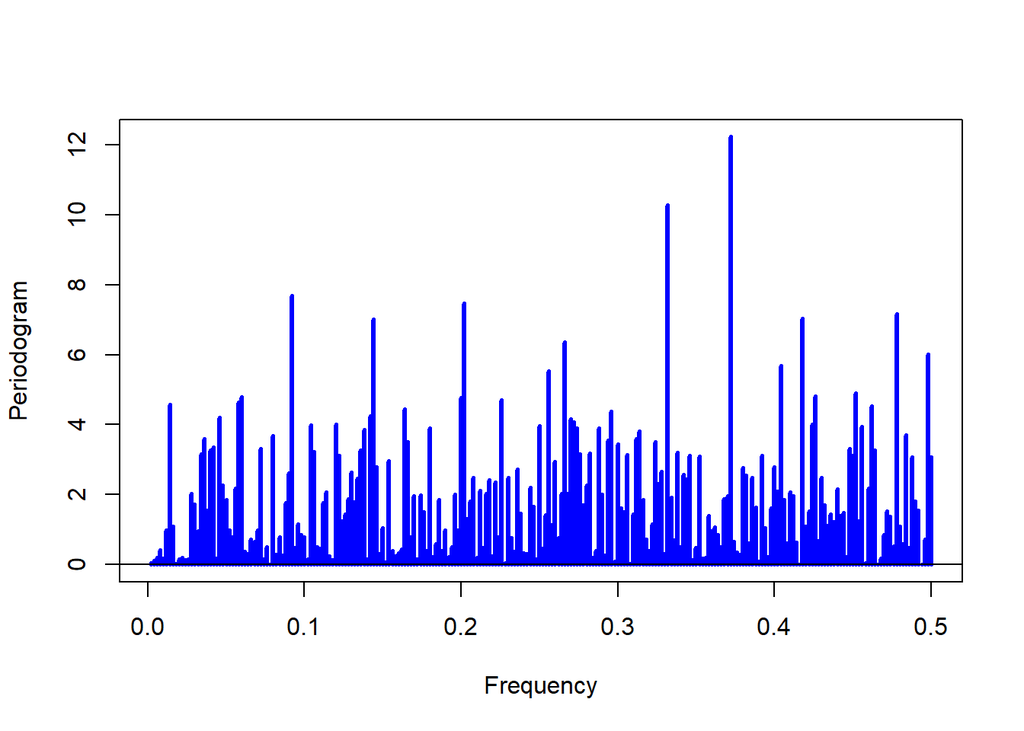

```r
periodogram(white_noise, col = "blue",lwd = 3)
abline(h=0)
```

Какого цвета еще бывают шумы можно прочитать и даже их послушать здесь https://en.wikipedia.org/wiki/Colors_of_noise

### Спектральная плотность ARMA(p,q) процесса

Для процессов ARMA(p,q) для спектральной плотности получен явный вид Для смешаных процессов произвольно порядка спектральную плотность удобно записывать через характеристические полиномы

$S(\lambda)= |\frac{\theta_q(e^{-2\pi i \lambda})}{\phi_p(e^{-2\pi i \lambda})}|^2\sigma_{\epsilon}^2$

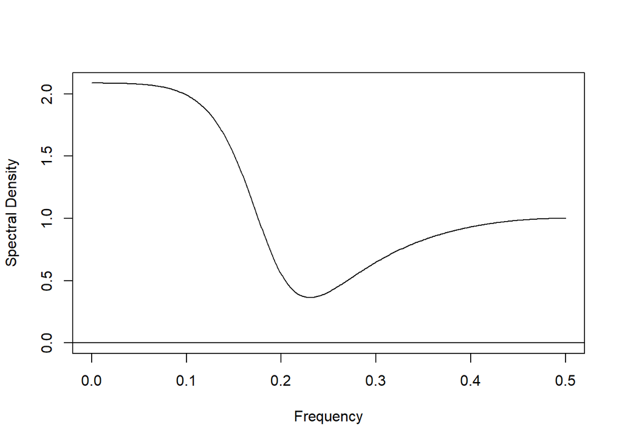

```r
phi_1 = 0.5
phi_2 = -0.4
theta_1 = -0.3
theta_2 = 0.6
ARMAspec(model = list(ar = c(phi_1,phi_2),ma = c(theta_1,theta_2)))
```

Подробнее с поведением спектральной плотности смешаного ARMA(p,q) процесса можно ознакомиться в следующем фрейме.

http://pc586s.cs.msu.ru:3838/Doynikov/ARMA_Model/ARMA%281%2C1%29/

## Оценка спектральной плотности по выборке

В качестве введения в проблемы, возникающие при оценке спектральной плотности, рассмотрим следующий численный пример. Пусть смоделирован процесс AR(1) c параметром $\phi=-0.7$.Длина выборки равна 200. Нам известны его свойства и вид спектральной плотности.

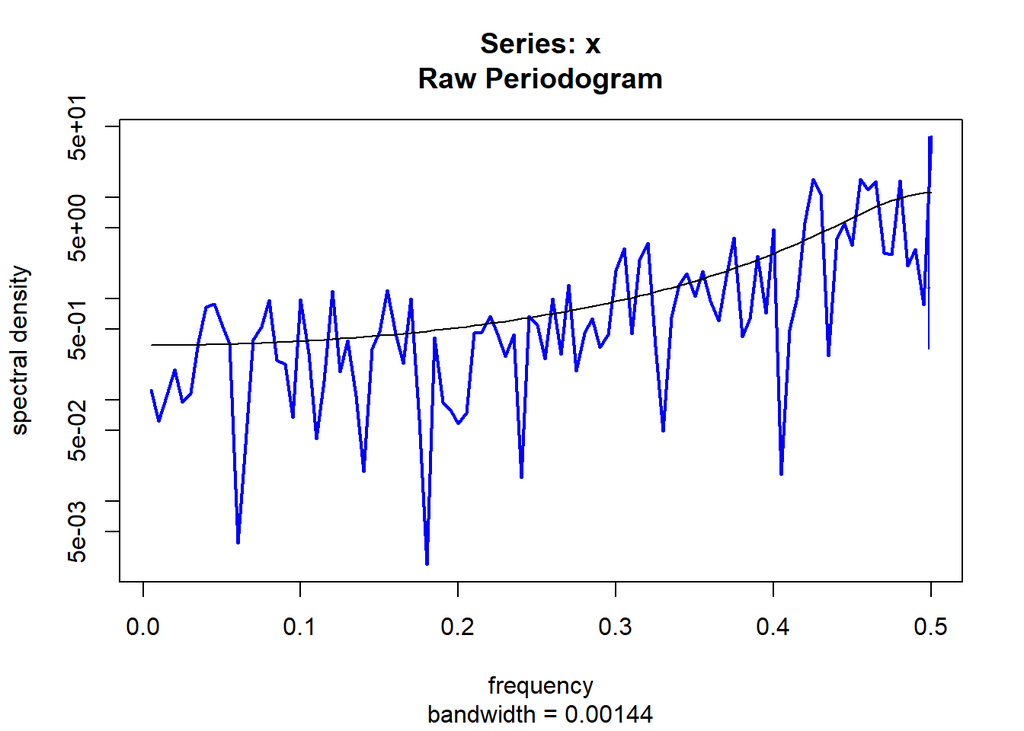

```r
n <- 200
phi <- -0.7
y <-arima.sim(model = list(ar = phi),n=n)
sp <- spec(y,col = "blue",lwd = 2,xlab= "frequency",ylab = "spectral density")
lines(sp$freq,ARMAspec(model = list(ar = phi),freq = sp$freq,plot= "F")$spec,lty = 1)
abline (h = 0)
```

Для изучения свойств оценки спектральной плотности предположим, что $y_t$ есть нормальный белый шум с дисперсией $c_0$. Мы уже знаем выражения для оценки амплитуд для частот $\lambda = j/n$

$A_{\lambda}= 2/n\sum_{t=1}^n y_t cos(2\pi t \lambda)$

$B_{\lambda}= 2/n\sum_{t=1}^n y_t sin(2\pi t \lambda)$

$A_{\lambda}$ и $B_{\lambda}$- линейные функции от $y_t$ следовательно обе имеют нормальное распределение. Можно оценить их математическое ожидание и дисперсию. Среднее будет 0, дисперсия $2c_0/n$. Более того так синус и косинус ортогональны то $A_{\lambda}$ и $B_{\lambda}$ будут некоррелированы, а значит в силу нормальности независимы для каждого $\lambda$. Сложнее показать, но поверим, что взаимно независимы будут $A_{\lambda_1},A_{\lambda_2},...$ и $B_{\lambda_1},B_{\lambda_2},...$. Квадрат нормальной сл. величины имеет хи-квадрат распределение с одной степенью свободы. Сумма независимых хи-квадрат имеет также хи-квадрат распределение с числом степеней свободы равной сумме степеней свободы каждой случайной величины. Таким образом

$n/2[A_{\lambda}^2+B_{\lambda}^2]= \frac{2\overline I(\lambda)}{f(\lambda)}$

имеет хи-квадрат распределение с двумя степенями свободы. Также имеем , что $\overline I_{\lambda_1}$ и $\overline I_{\lambda_2}$ независимы при $\lambda_1 \ne \lambda_2$. И

$E[\overline I_{\lambda}]= f({\lambda})$

$D[\overline I_{\lambda}]= f({\lambda})^2$

К сожалению последние выражения не зависят от длины выборки $n$. Это означает, что выборочная спектральная плотность не являетя состоятельной оценкой теоретической спектральной плотности. Увеличение длины выборки не приведет к более гладкой оценке. Одним из возможных решений, но неудобных на практике, это повторить моделирование много раз и усреднить оценку

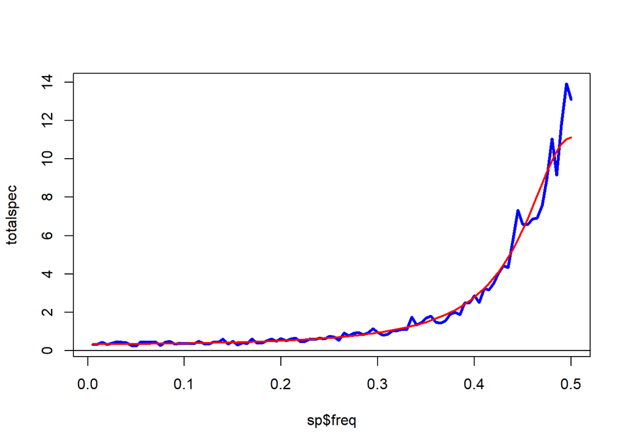

```r
n <- 200
phi <- -0.7
y <-arima.sim(model = list(ar = phi),n=n)
sp <- spec(y,col = "blue",lwd = 2,xlab= "frequency",plot = FALSE,ylab = "spectral density")
totalspec <- sp$spec
m <- 40
for (i in 2:m)
{
  y <-arima.sim(model = list(ar = phi),n=n)
  sp <- spec(y,col = "blue",lwd = 2,xlab= "frequency",plot = FALSE,ylab = "spectral density")
  totalspec <- totalspec + sp$spec
}
totalspec <- totalspec/m
plot(sp$freq,totalspec,type = "l", col = "blue", lwd = 3)
lines(sp$freq,ARMAspec(model = list(ar = phi),freq = sp$freq,plot= "F")$spec,lty = 1,lwd =2,col = "red")
abline (h = 0)
```

Картина становится лучше,но на практике такой прием мало применим. Чаше всего имеется одна выборка и необходимо получить достаточно гладкую оценку плотности.

В качестве одного из свойст выборочной периодограммы была отмечена ее несостоятельность как оценки спектральной плотности. Для того, чтобы преодолеть этот недостаток мы пришли к понятию сглаженной периодограммы

### Сглаженная оценка спектральной плотности

Основная идея ,так как спектральная плотности не сильно меняется при малом изменении частоты, то мы будем усреднять оценку на близких частотах. Итак мы пришли к понятию сглаженной спектральной плотности. Зададим некоторое произвольное число $m>0$, которое будем называть шириной окна и с весами $\frac{1}{2m+1}$ усредним выборочную спектральную плотность

$\overline{f}(\lambda)= \frac{1}{2m+1} \sum_{j=-m}^mf(\lambda+j/n)$

Другими словами мы сгладили спектральную плотность с помощью спектрального окна $W_m(\lambda)$ ширины $m$ свойства которого.

$1.W_m(k)>0$

$2.W_m(k)=W_m(-k)$

$3.\sum_{k=-m}^m W_m(k)=1$

и получили сглаженную спектральную плотность

$\overline{f}(\lambda)= \sum_{j=-m}^m W_m(k)f(\lambda+j/n)$

Веса $\frac{1}{2m+1}$ называют простым спектральным окном, еще его называют спектральным окном Даниелла по имени того, кто первым использовал это в 1940 году.

Для примера рассмотрим сглаживание спектралной плотности с помошью окна Даниелла

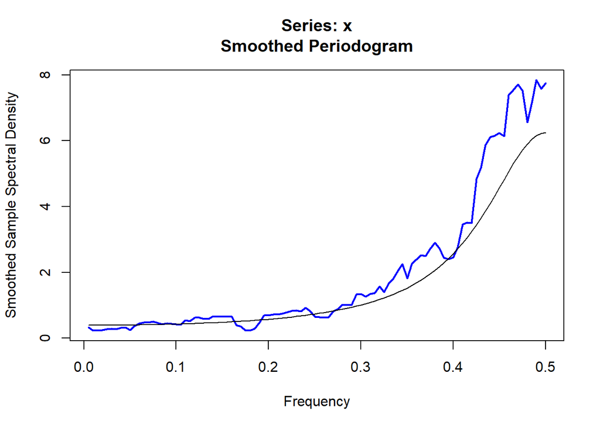

```r
library(TSA)
set.seed(271435); n=200; phi=-0.6
y=arima.sim(model=list(ar=phi),n=n)
k=kernel('daniell',m=5)
sp=spec(y,kernel=k,log='no',sub='',xlab='Frequency',
ylab='Smoothed Sample Spectral Density',col = "blue",lwd = 2)
lines(sp$freq,ARMAspec(model=list(ar=phi),freq=sp$freq,
plot=F)$spec,lty=1)
```

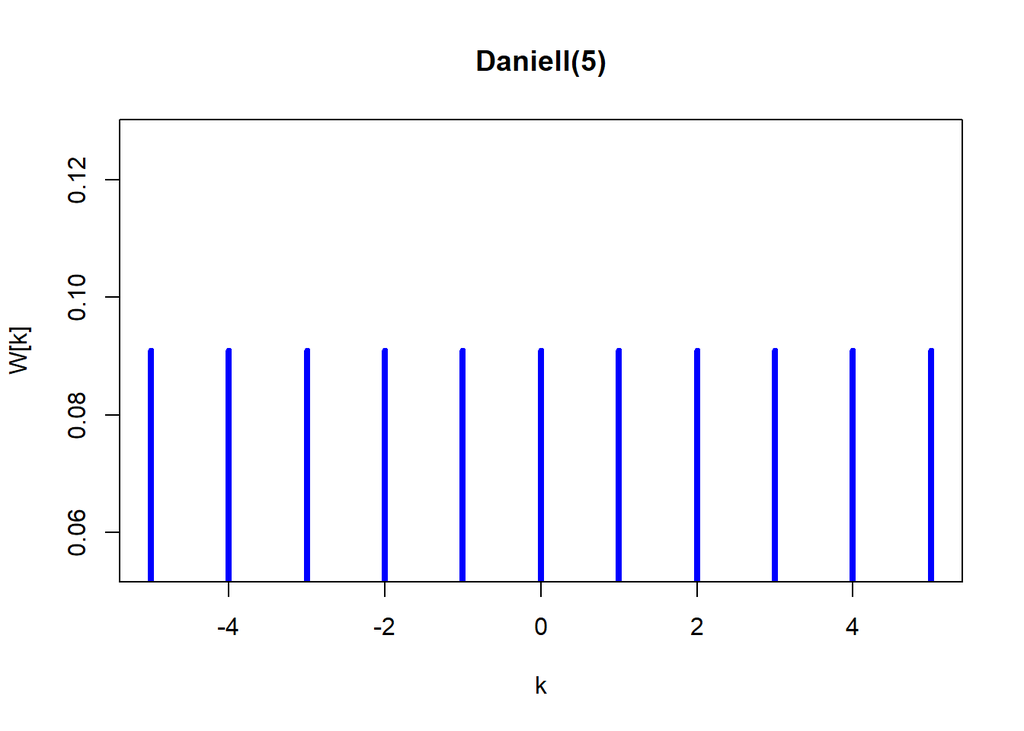

```r
plot(k,type= "h",lwd = 4,col = "blue")
```

В последующие годы было предложено масса других спектральных окон. Один из подходов здесь неоднократное повторение процедуры сглаживания с одним и тем же окном в частности Даниелла. Это как бы свертка окон.

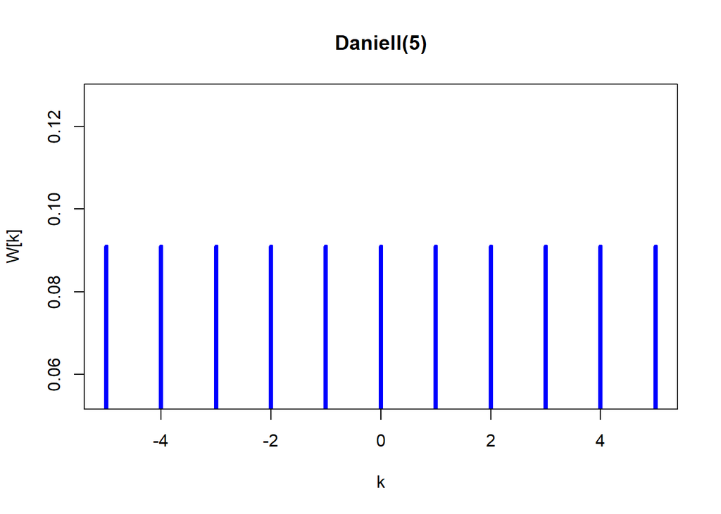

```r
k<- kernel('daniell',5)
k2<- kernel('daniell',c(5,5))
plot(k,type= "h",lwd = 4,col = "blue")
```

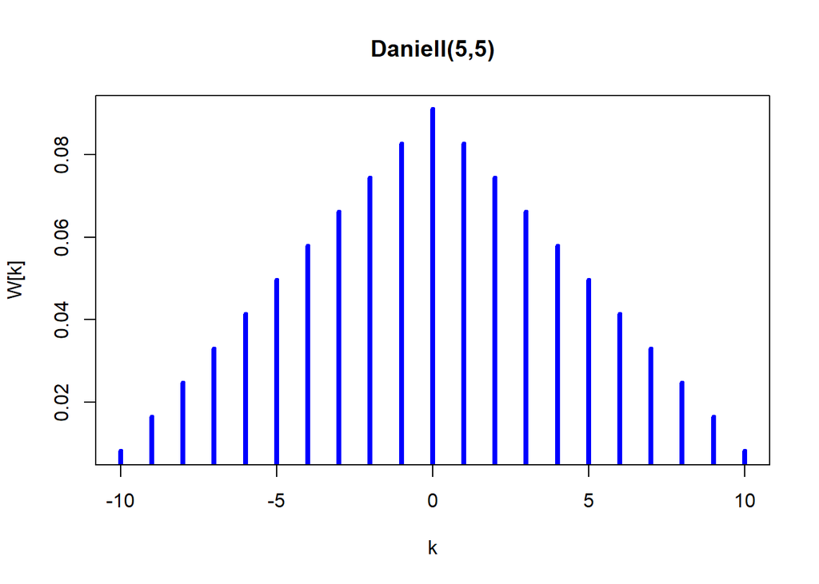

```r
plot(k2,type= "h",lwd = 4,col = "blue")
```

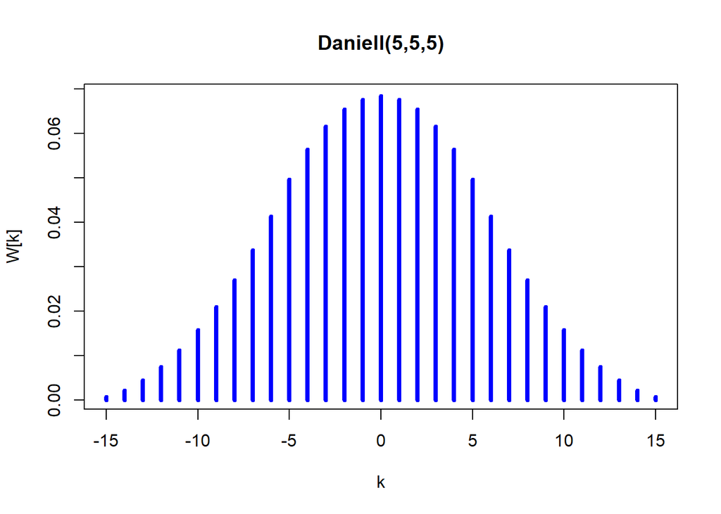

```r
k3<- kernel('daniell',c(5,5,5))
plot(k3,type= "h",lwd = 4,col = "blue")
```

Сгладим ранее смоделированный ряд с этим окном и сравним с прошлыми результатами сглаживания и выборочной периодограммой

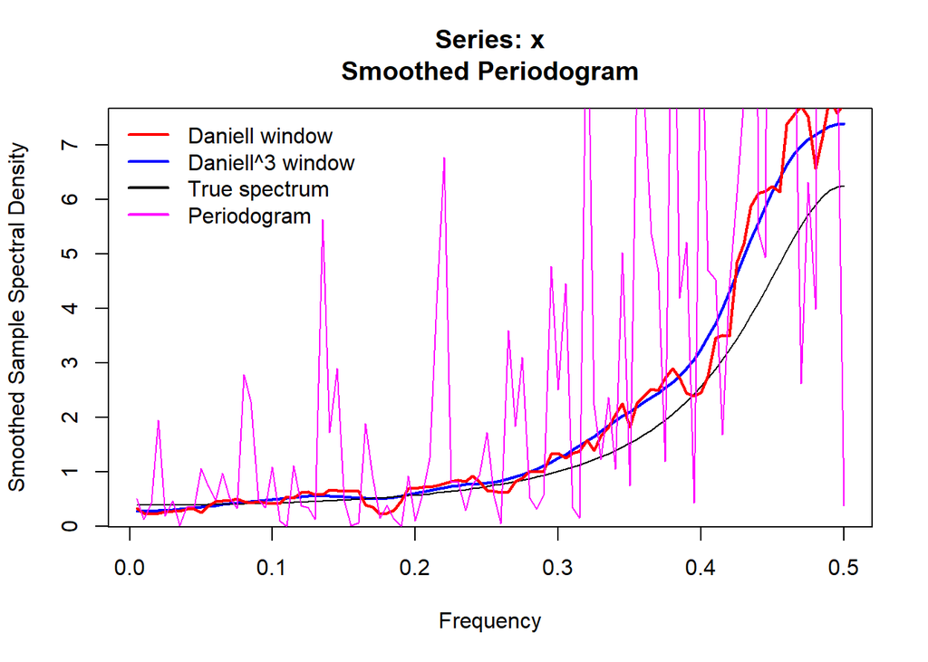

```r
sp3=spec(y,kernel=k3,log='no',sub='',xlab='Frequency',
ylab='Smoothed Sample Spectral Density',col = "blue",lwd = 2)
lines(sp$freq,ARMAspec(model=list(ar=phi),freq=sp$freq,
plot=F)$spec,lty=1)
lines(sp$freq,sp$spec,lwd = 2,col = "red")
legend("topleft",c("Daniell window","Daniell^3 window","True spectrum","Periodogram"),bty="n",lwd = 2,col = c("red","blue","black","magenta"))
per <- periodogram(y,plot = FALSE)
lines(per$freq,per$spec,col = "magenta")
```

Выбор ширины окна важная задача. Чатфилд (Chatfield) 2004 предложил выбирать ширину окна $m = \sqrt{n}$ Другие предлагают вариант $m=2\sqrt{n}$

### Корреляционное окно

Здесь мы вспомним, что спектр это косинус преобразование Фурье автокорреляционной функции

$\overline{f}(\lambda)= \sum_{k=-m}^m W(k)f(\lambda+k/n)=$

$\sum_{k=-m}^m W(k)[\sum_{j=-n+1}^{n-1}c_j e^{-2\pi i (\lambda+k/n)j}]=$

$\sum_{j=-n+1}^{n-1}c_j[\sum_{k=-m}^m W(k)e^{-2\pi i k/nj}]e^{-2\pi i \lambda j}$

Выражение в квадратных скобках обозначим через $w(j/n)$

$w(j/n)= \sum_{k=-m}^m W(k)e^{-2\pi i k/nj}$

Итак

$\overline{f}(\lambda) = \sum_{j=-n+1}^{n-1}w(j/n)c_j cos(2\pi\lambda j)$

функция $w(x)$ имеет свойство

$w(x)= w(-x)$

$w(0)= 1$

$w(x) <= 1$

поэтому $w(x)$ называют корреляционным окном

### Примеры корреляционных окон

1.Прямоугольное окно $w(j/n)= 1$ при $|j| <= m$ Здесь $m$ ширина корреляционного окна

2. Треугольное окно

$w(j/n)= 1- |j/m|$ при при $|j| <= m$

### Энцефалограмма головного мозга (ЭЭГ)

Наблюдения снимаются аппаратом ЭКГ 128 раз в секунду, т.е. интервал между наблюдением равен 0.0078 сек.

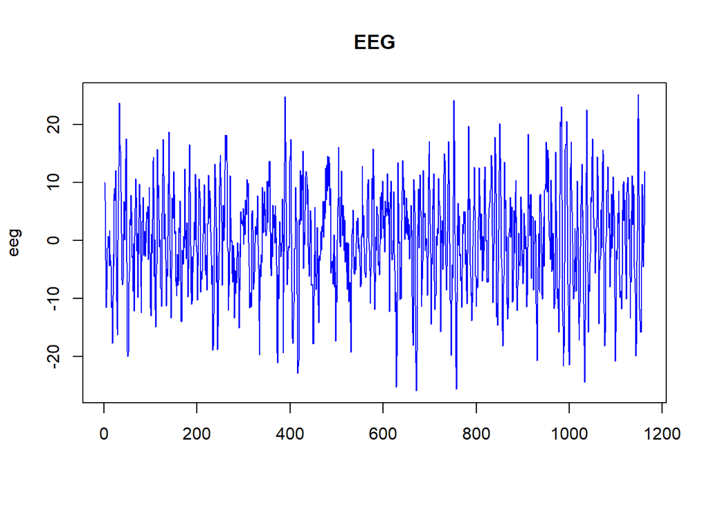

```r
eeg <- read.csv("c:/ShurD/aLection/EEG.csv")
matplot(eeg,type ="l",col = "blue",main= "EEG")
```

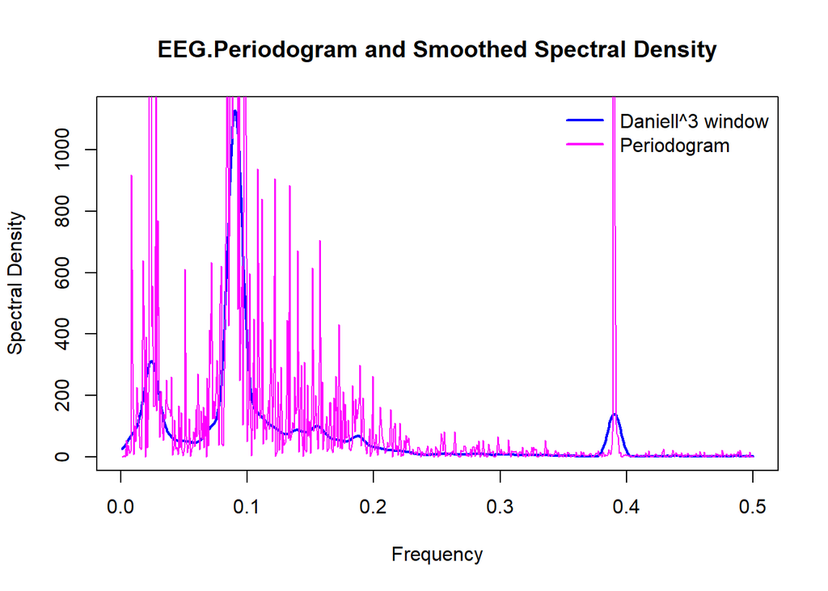

```r
k3<- kernel('daniell',c(5,5,5))
eegspec=spectrum(eeg,kernel=k3,log='no',sub='',xlab='Frequency',main = "EEG.Periodogram and Smoothed Spectral Density",
ylab='Spectral Density',col = "blue",lwd = 2)
pereeg <- periodogram(eeg,plot = FALSE)
lines(pereeg$freq,pereeg$spec,col = "magenta")
legend("topright",c("Daniell^3 window","Periodogram"),bty="n",lwd = 2,col = c("blue","magenta"))
```

Как вычислить частоту в герцах. Предположим имеется пик на частоте 0.1, это соответсвует периоду 1/0.1 = 10 интервалов времени. Длительность одного интервала времени 1/128 = 0.0078 секунды. Длительность одного периода 0.0078 *10 = 0.078 секунды следовательно это составит 1/0.078 = 12.82 Герц.

Первый пик слева находится на частоте 0.02 второй на 0.09, что соответсвует периодам 1/0.02 = 50, второй 1/0.09= 11.1. В секундах периоды равны соответственно 50 * 0.0078 сек.= 0.39 сек. и 11.1 *0.0078 = 0.086 сек.. Выразим их в герцах 1/0.39 = 2.7 Гц. и 1/0.86 = 11.5 Гц. $\alpha$ ритм мозга имеет частоты 9-13 Гц. ;$\delta$ ритм 1-3 Гц.

#Кепстральный анализ#

Пусть $x(t),t=0,±1,±2,...$ , - стационаpный случайный пpоцесс. Пусть $f(λ)$ спектpальная плотность пpоцесса.

Известно, что пpи условии
$$\int_{-0.5}^{0.5}ln f(λ)dλ>-∞$$
спектpальная плотность пpедставима в виде

$$f(λ)=|\phi(e^{2πiλ})|^2$$

пpичем функция $\Phi(•)$ удовлетвоpяет pавенству
$$\Phi(e^{2πiλ})=∑_{j=-∞}^{∞}\phi_{j}e^{2πiλj}$$
$\phi_{j}$ - коэффициенты Фуpье функции $\Phi(•)$, а сама функция $\Phi(•)$ - пpеобpазование Фуpье последовательности $\phi_{j}$. Аналогичное pазложение в pяд с помощью пpеобpазования Фуpье спpаведливо и для логаpифма $\Phi(•)$:
$$ln\Phi(e^{2πiλ})=∑_{j=-∞}^{∞}l_{j}e^{2πiλj}$$
Последовательность коэффициентов $l_{j}$ последнего разложения как функцию от $j$ называют кепстpом. Кепстp может быть вычислен с помощью коэффициентов $\phi_{j}$ из уpавнения
$$e^{l_0+l_1z+l_2z^2+...}=\phi_0+\phi_1z+\phi_2z^2+...$$
Впеpвые последовательность ${l(j)}$ введена в pассмотpение А.Н.Колмогоpовым пpи постpоении теоpии стационаpных случайных последовательностей. Уpавнение называется уpавнением Колмогоpова. Разложение называют pядом уpавнения Колмогоpова (в английском ваpианте - “Kolmogorov Equation Power Series”, или, сокpащенно, KEPS). Используя теpминологию теоpии линейных пpеобpазований случайных пpоцессов, коэффициeнты pазложения (*) можно интеpпpетиpовать как вpеменной отклик линейной системы (Time Responce). Поэтому полное название функции $l(j)$ после добавления латинского окончания получается KEPSTRUM. В иностранной литературе её также называют CEPSTRUM, изменяя слово «спектр» («spectrum») и объясняя это тем, что «в общем случае мы действуем в частотной области так, как принято действовать во временной, и наоборот». При этом новое «кепстральное» время было ими названо термином «quefrency» (от английского «frequency»).

Кепстp удобен пpи pассмотpении случайных пpоцессов, пpедставимых в виде свеpтки двух последовательностей

$$X_{t}=\sum_{k=-∞}^{∞}Y_{k}Z_{t-k}$$
Так как кепстр сверки равен сумме кепстров составляющих
$$l_{x,i}=l_{y,i}+l_{z,i}$$
Это позволяет восставновить один из сигналов если при этом известны характеристики другого сигнала и их свертки. Частным случаем такой свеpтки является смесь некотоpого сигнала и его эха
$$X_{t} = Y_{t}, t=1,...m;$$
$$X_t= Y_{t}+AY_{t-m}, t = m+1,m+2$$
Нетрудно убедиться, что если $f_{y}(λ)$ процесса $Y_t$, то спектр $f_{x}(λ)$ процесса $X_t$ будет равен
$$f_{x}(λ)=f_{y}(λ)[1+A^2+2Acos(2πλm)]$$
,

Доказательство этого факта несложно. При $t = m+1,m+2,...$ умножим $X_t$ на $X_{t+k}$ и возьмем мат. ожидание обеих частей
$$EX_{t}X_{t+k}=E(Y_{t}+AY_{t-m})(Y_{t+k}+AY_{t+k-m})=$$
$$EY_{t}Y_{t+k}+AEY_{t-m}Y_{t+k}+AEY_{t}Y_{t+k-m}+A^2EY_{t-m}Y_{t+k-m} =
c_{k}+Ac_{m+k}+Ac_{k-m}+A^2c_{k}$$
Вычислим спектр, используя его определение.
$$f_{x}(λ)=∑_{k=-∞}^{∞}(c_{k}+Ac_{k+m}+Ac_{k-m}+A^2c_{k})e^{2πiλk}$$
Каждое слагаемое вычислим отдельно.
$$∑_{j=-∞}^{∞}c_{j}e^{2πiλj}=f_y(λ)$$
$$∑_{j=-∞}^{∞}c_{j-m}e^{2πiλj}=∑_{k=-∞}^{∞}c_{k}e^{2πiλ(k+m)}=e^{2πiλm}∑_{k=-∞}^{∞}c_{k}e^{2πiλk}=e^{2πiλm}f_y(λ)$$
$$∑_{j=-∞}^{∞}c_{j+m}e^{2πiλj}=∑_{k=-∞}^{∞}c_{k}e^{2πiλ(k-m)}=e^{-2πiλm}∑_{k=-∞}^{∞}c_{k}e^{2πiλk}=e^{-2πiλm}f_y(λ)$$
$$Af_y(λ)(e^{2πiλm}+e^{-2πiλm}) = Af_y(λ)(cos2πλm+isin2πλm+cos2πλm-isin2πλm)=
2Af_y(λ)cos2πλm$$
Собираeм все воедино, получим требуемое выражение.

Таким образом с точностью до $A^2$ добавление эха приводит к появлению в спектре косинусоидального колебания частота которого связана с задержкой $m$ эха. Особенно заметно появление косинусоидальной составляющей в случае,когда $Y_t$ - процесс белого шума, у которого $f_y(\lambda)$ спектральная плотность константа.

Посмотрим как это отобразится на периодограмме. Для этого нам необходимо написать функцию, которая добавляет эхо эффект на заданной задержке в произвольный временной ряд.

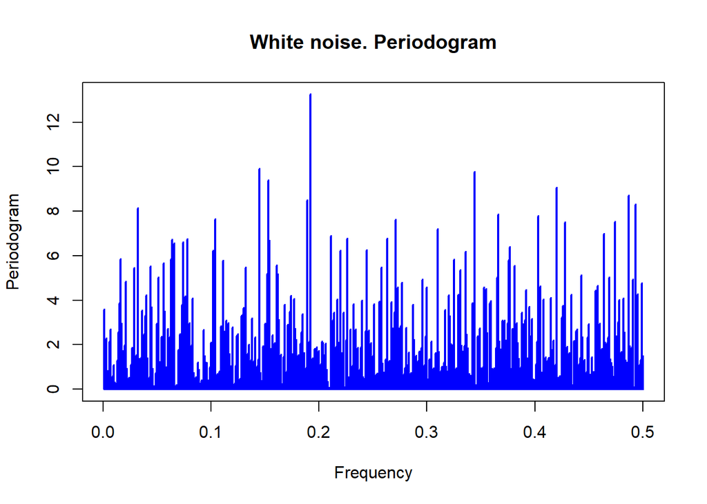

```r
library(TSA)
addecho<-function(w,Magnit,delayIndex)
{

  Coeff <- Magnit;
  Shift <- delayIndex;
  resl = w
  m <- length(w)

  for( i in (Shift+1):m)
  {
    dl = w[i-Shift]
    if (is.na(w[i])== FALSE)
    {
      dd <- w[i]+ Coeff*dl
      resl[i] <- dd
    }
    else
      resl[i]<-NA
    resl[i] <- as.integer(resl[i])
  }
  return(resl)
}
r <-rnorm(1000)
require('TSA')
periodogram(r,log="no",col = "blue",main = "White noise. Periodogram"  )
```

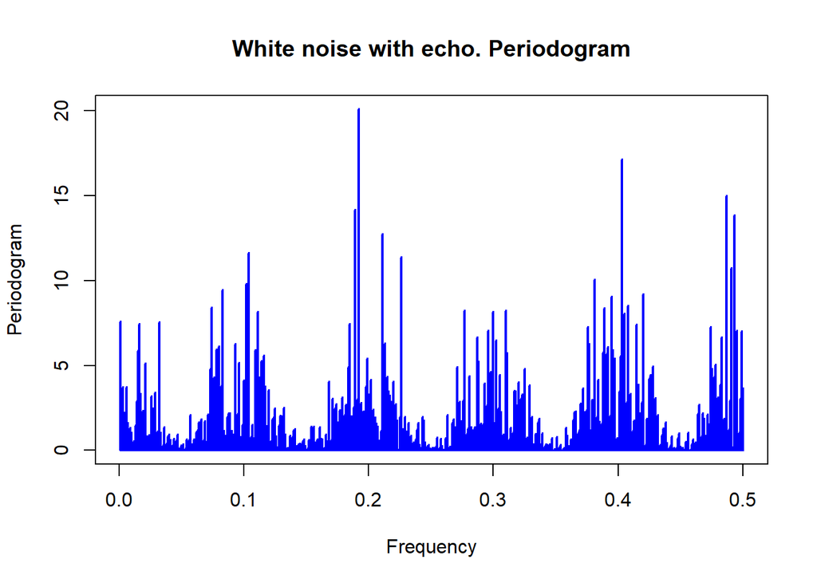

```r
echor <- addecho(r,0.9,10)
periodogram(echor,log="no",col = "blue",main = "White noise with echo. Periodogram")
```

Особенно это будет заметно на сглаженной периодограмме

```r
sp3=spec(echor,kernel=k3,log='no',sub='',xlab='Frequency',
ylab='Smoothed Sample Spectral Density',col = "blue",lwd = 2)
```

[figure not shown]

```r
#lines(sp3$freq,sp3$spec,lwd = 2,col = "red")
```

Хорошо заметны косинусоидальные колебания. Частота их 0.1. Период $T=1/0.1=10$ именно 10 была задержка добавленного эхо. Теперь оценим кепстр. По определению это действительная чась обратного преобразования Фурье от логарифма преобразование Фурье ряда. Для быстроты вычислений будем использовать алгоритм быстрого преобразования Фурье.

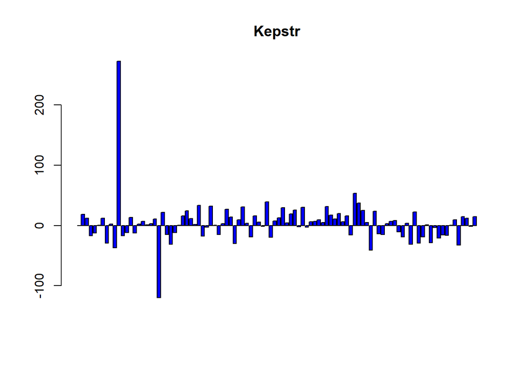

```r
  l <- Re(fft(log(abs(fft(echor))), inverse = TRUE))
  l[1]=0
  barplot(l[1:100],col = "blue",main="Kepstr")
```

На полученном графике кепстра отчетливо выделяется пик на задержке равной 10.

О том как эхо эффекты влияют на ARMA процессы можно посмотреть здесь https://shiny.ilykei.com/ANDoynikov/ARMA_Model/AR(2)%20Model/ на примере AR(2).

Наиболее интересное и важное приложение кепстра находится в области работы со звуком. Работе со звуком посвящены библиотеки языка R library(seewave) и library(tuneR) в них и обнаружим метод ceps(…) для оценки кепстра. Для примера возьмем звуковой файл sheep из библиотеки library(seewave) и послушаем его.

```r
library(seewave)
library(tuneR)
data(sheep)
#listen(sheep)
```

Временной ряд звукового сигнала выглядит следующим образом

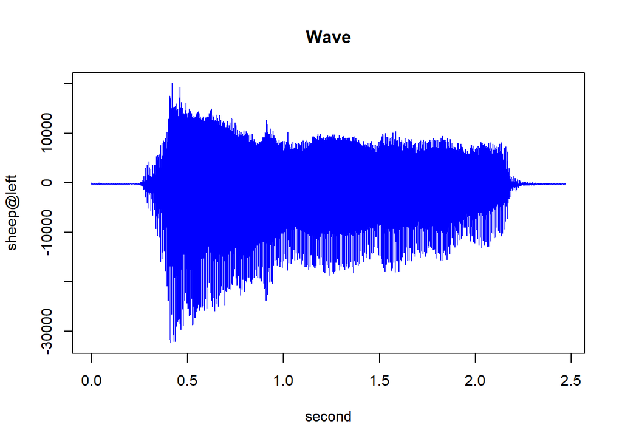

```r
    N <- length(sheep@left)
    xt <- seq(0, N/sheep@samp.rate, length.out = N)
    matplot(xt,sheep@left,type ="l",xlab = "second",col="blue",main = "Wave")
```

Добавим к нему 2 эхо на задержке 0.3 и 1 сек с амплитудой 0.9 и послушаем результат. Для этого перепишем наш метод addecho для звукового сигнала. Обратите внимание, что этод метод может добавлять эхо в оба канала, в случае стерео сигнала.

```r
addecho1<-function(w,Magnit,f,delay)
{

  delayIndex <-as.integer(delay/(1 / f))+1
  Coeff <- Magnit;
  Shift <- delayIndex;
  resl = w@left
  m <- length(resl)
  ret <- w
  for( i in (Shift+1):m)
  {
    dl = w@left[i-Shift]
    if (is.na(w@left[i])== FALSE)
    {
      dd <- as.integer(w@left[i]+ Coeff*dl)
      resl[i] <- dd
    }
    else
      resl[i]<-NA
    resl[i] <- as.integer(resl[i])
  }
  ret@left <- resl
  if (w@stereo== TRUE)
  {
    resr <- w@right
    for( i in (Shift+1):m)
    {
      dr = w@right[i-Shift]
      resr[i] <-resr[i]+ Coeff*dl
    }
    ret@right <- resr
  }
  return(ret)
}

echo1 <- addecho1(sheep,0.9,sheep@samp.rate,0.3)
echo2 <- addecho1(echo1,0.9,sheep@samp.rate,1.0)
#listen(echo2)
```

После добавления эхо эффектов временной ряд сигнала стал таким

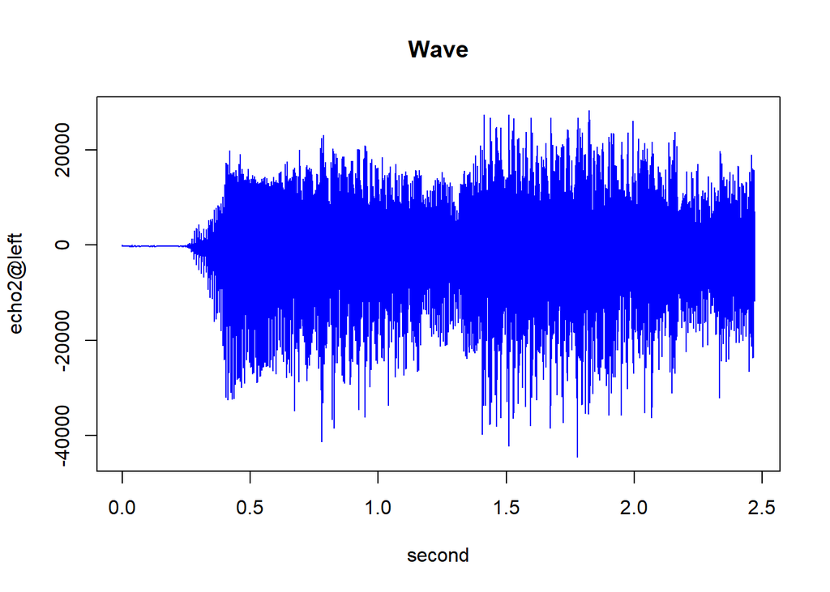

```r
    N <- length(echo2@left)
    xt <- seq(0, N/echo2@samp.rate, length.out = N)
    matplot(xt,echo2@left,type ="l",xlab = "second",col="blue",main = "Wave")
```

Построим кепстр сигнала с этими двумя эхо.

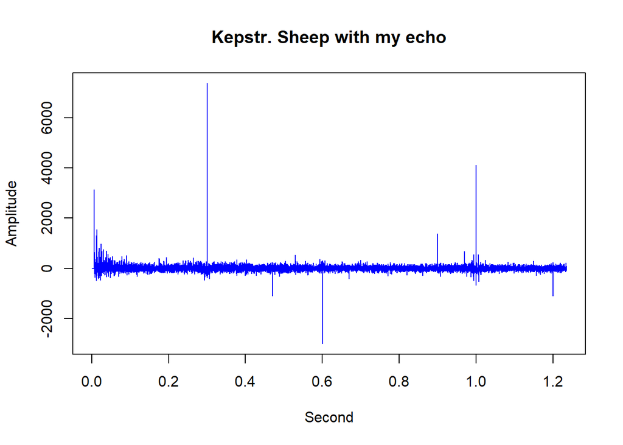

```r
lecho<-ceps(echo2,echo2@samp.rate,wl=512,plot = FALSE,lwd = 2,col = "blue",main = "Sheep Kepstrum")
lecho[1:50,2]<- 0
matplot(lecho[,1],lecho[,2],type = "l",xlab = "Second",ylab = "Amplitude",col = "blue",main = "Kepstr. Sheep with my echo" )
```

Обратите внимание на экспоненциальное затухание в кепстре эффекта от каждого эхо. Я не обнаружил в этих библиотеках метода для удаления эхо.Пришлось его также написать самостоятельно.

```r
deleteecho<-function(w,kep,f,delay,Magnit)
{

  kepnum <- as.vector(kep[,2],mode = "numeric")
  n <- length(kepnum)
  delayIndex <-as.integer(delay/(1 / f))
  delayIndex <- min(delayIndex,n)+1
  Coeff <- -Magnit;
  Shift <- delayIndex;
  resl = w@left
  m <- length(resl)
  ret <- w
  while(Shift <= m)
  {
    for(i in (Shift+1):m)
    {
      dl = w@left[i-Shift]
      resl[i] <- as.integer(resl[i]+ Coeff*dl)
    }
    Shift <- Shift + delayIndex;
    Coeff <- -Coeff*Magnit;
  }
  ret@left <- resl
  if (w@stereo== TRUE)
  {
    Coeff <- -Magnit;
    Shift <- delayIndex;
    resr = w@right
    m <- length(resr)
    while(Shift <= m)
    {
      for(i in (Shift+1):m)
      {

        dr = w@right[i-Shift]
        resr[i] <- as.integer(resr[i]+ Coeff*dr)
      }
      Shift <- Shift + delayIndex;
      Coeff <- -Coeff*Magnit;
    }
    ret@right <- resr
  }

  return(ret)
}
```

С помощью этого метода последовательно удалим оба эхо на задержке 0.3 и 1 секунды. Опять посмотрим на кепстр сигнала после удаления эхо.

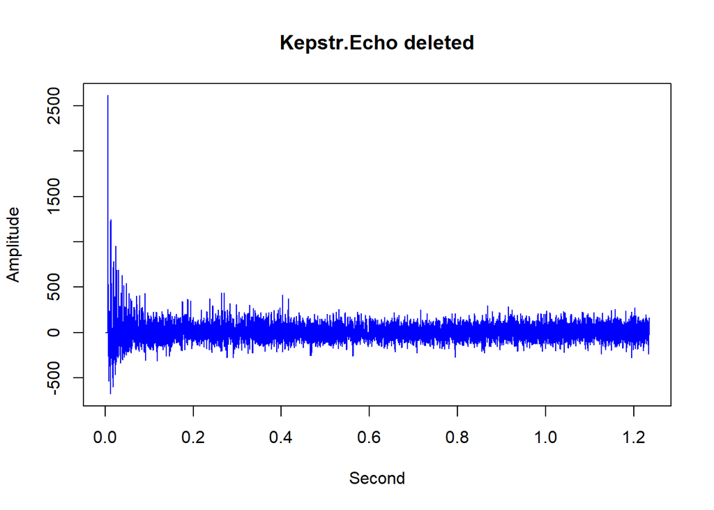

```r
d1 <- deleteecho(echo2,lecho,sheep@samp.rate ,0.3,0.9)
d2 <- deleteecho(d1,lecho,sheep@samp.rate ,1.0,0.9)
decho<-ceps(d2,echo2@samp.rate,wl=512,plot = FALSE,lwd = 2,col = "blue",main = "Sheep Kepstrum")
decho[1:50,2]<- 0
matplot(decho[,1],decho[,2],type = "l",xlab = "Second",ylab = "Amplitude",col = "blue",main = "Kepstr.Echo deleted" )
```

И послушаем то, что получилось.

```r
#listen(d2)
```

Сигнал восстановлен. https://shiny/ilikey.com/ANDoynikov/cepstrum